# NN_Project_Part_2

## Importing Standard Libraries

```python
## Ignore warnings

import warnings
warnings.filterwarnings('ignore')

## Pandas and Numpy

import numpy as np
import pandas as pd

## Plotting libraries

import matplotlib.pyplot as plt
import seaborn as sns

## Stats libraries

from scipy.stats import zscore
import statsmodels.api as sm
from statsmodels.formula.api import ols

## Tensorflow

import tensorflow
```

## Importing the dataset

```python
import h5py
filename = "Part - 4 - Autonomous_Vehicles_SVHN_single_grey1.h5"

with h5py.File(filename, "r") as f:
    # List all groups
    print(f.keys())
```

```
<KeysViewHDF5 ['X_test', 'X_train', 'X_val', 'y_test', 'y_train', 'y_val']>
```

```python
## Extracting the data from the h5py file

with h5py.File(filename, "r") as f:
    key0 = list(f.keys())[0]
    key1 = list(f.keys())[1]
    key2 = list(f.keys())[2]
    key3 = list(f.keys())[3]
    key4 = list(f.keys())[4]
    key5 = list(f.keys())[5]

    # Get the data
    X_test = np.array(list(f[key0]))
    X_train = np.array(list(f[key1]))
    X_val = np.array(list(f[key2]))
    y_test = np.array(list(f[key3]))
    y_train = np.array(list(f[key4]))
    y_val = np.array(list(f[key5]))
```

#### Checking the shape of the datasets

```python
(X_test.shape, y_test.shape)
```

```
((18000, 32, 32), (18000,))
```

```python
(X_train.shape, y_train.shape)
```

```
((42000, 32, 32), (42000,))
```

```python
(X_val.shape, y_val.shape)
```

```
((60000, 32, 32), (60000,))
```

```
Label:2
```

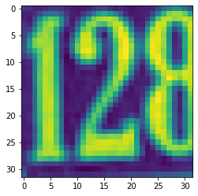

```python
## Visualizing some data points (images)

import matplotlib.pyplot as plt

print (f"Label:{y_train[0]}")
plt.imshow(X_train[0]);
```

```
Label:7
```

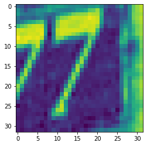

```python
print (f"Label:{y_train[4000]}")
plt.imshow(X_train[4000]);
```

```
Label:8
```

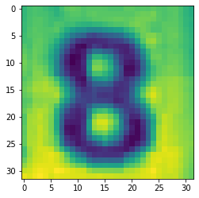

```python
print (f"Label:{y_train[28000]}")
plt.imshow(X_train[28000]);
```

```
Label:4
```

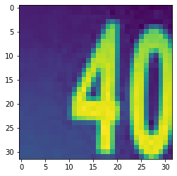

```python
print (f"Label:{y_val[18000]}")
plt.imshow(X_val[18000]);
```

```python
np.unique(y_train)
```

```
array([0, 1, 2, 3, 4, 5, 6, 7, 8, 9], dtype=uint8)
```

## Model building preparation

#### Reshaping the features

```python
X_train = X_train.reshape(42000, 1024)
print(X_train.shape)

X_val = X_val.reshape(60000, 1024)
print(X_val.shape)

X_test = X_test.reshape(18000, 1024)
print(X_test.shape)
```

```
(42000, 1024)
(60000, 1024)
(18000, 1024)
```

#### Scaling the features

```python
## Checking maximum and minimum values

print(X_train.max(), X_train.min())
print(X_val.max(), X_val.min())
print(X_test.max(), X_test.min())
```

```
254.9745 0.0
254.9745 0.0
254.9745 0.0
```

```python
## Scaling

X_train = X_train/255.0
X_val = X_val/255.0
X_test = X_test/255.0
```

```python
## Checking maximum and minimum values

print(X_train.max(), X_train.min())
print(X_val.max(), X_val.min())
```

```
0.9999 0.0
0.9999 0.0
```

#### One-Hot Encode the class vector

```python
print(y_train[10])

y_train = tensorflow.keras.utils.to_categorical(y_train,num_classes = 10)
y_val = tensorflow.keras.utils.to_categorical(y_val,num_classes = 10)
y_test = tensorflow.keras.utils.to_categorical(y_test,num_classes = 10)

print(y_train[10])
```

```
1
[0. 1. 0. 0. 0. 0. 0. 0. 0. 0.]
```

## Model Creation

```python
## Importing TF libraries

from tensorflow.keras.models import Sequential
from tensorflow.keras.layers import Dense
from tensorflow.keras import regularizers, optimizers
```

```python
## creating the model

model1 =  Sequential()
model1.add(Dense(256, input_shape = (1024,), activation = 'relu'))
model1.add(Dense(256, activation = 'relu'))
model1.add(Dense(10, activation = 'softmax'))

## optimizer

sgd = optimizers.SGD(lr = 1e-4, decay = 1e-6, momentum = 0.9)

## compiling the model

model1.compile(loss = 'categorical_crossentropy', optimizer = sgd, metrics = ['accuracy'])

## fitting the model

history1 = model1.fit(X_train, y_train, epochs = 20, batch_size = 1000, verbose = 1, validation_data= (X_val,y_val))
```

```python
def plots(history):
    df = pd.DataFrame(history.history)
    fig, (ax1, ax2) = plt.subplots(1,2, figsize = (15,5))
    ax1.plot(np.array(df.index), df.loss , '-b', label='Training Loss')
    ax1.plot(np.array(df.index), df.val_loss, '--r', label='Validation Loss')
    ax2.plot(np.array(df.index), df.accuracy , '-b', label='Training Accuracy')
    ax2.plot(np.array(df.index), df.val_accuracy, '--r', label='Validation Accuracy')

    leg1 = ax1.legend();
    leg2 = ax2.legend();
```

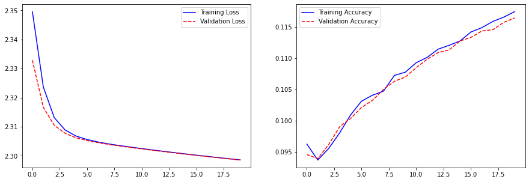

```python
plots(history1)
```

### We see that the drop in loss and increase in accuracy is quite slow. We can increase the learning rate to see if it improves

```python
## creating the 2nd model

model2 =  Sequential()
model2.add(Dense(256, input_shape = (1024,), activation = 'relu'))
model2.add(Dense(256, activation = 'relu'))
model2.add(Dense(10, activation = 'softmax'))

## optimizer

sgd = optimizers.SGD(lr = 1, decay = 1e-6, momentum = 0.9) ## New learning rate of 1

## compiling the model

model2.compile(loss = 'categorical_crossentropy', optimizer = sgd, metrics = ['accuracy'])

## fitting the model

history2 = model2.fit(X_train, y_train, epochs = 20, batch_size = 1000, verbose = 1, validation_data= (X_val,y_val))
```

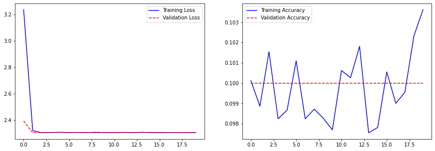

```python
plots(history2)
```

### We see that the model training happens the validation accuracy and loss remain the same throughout. We can keep the learning rate between the two earlier values to see if it improves

```python
## creating the 3rd model

model3 =  Sequential()
model3.add(Dense(256, input_shape = (1024,), activation = 'relu'))
model3.add(Dense(256, activation = 'relu'))
model3.add(Dense(10, activation = 'softmax'))

## optimizer

sgd = optimizers.SGD(lr = 0.01, decay = 1e-6, momentum = 0.9) ## New learning rate of 0.01

## compiling the model

model3.compile(loss = 'categorical_crossentropy', optimizer = sgd, metrics = ['accuracy'])

## fitting the model

history3 = model3.fit(X_train, y_train, epochs = 20, batch_size = 1000, verbose = 1, validation_data= (X_val,y_val))
```

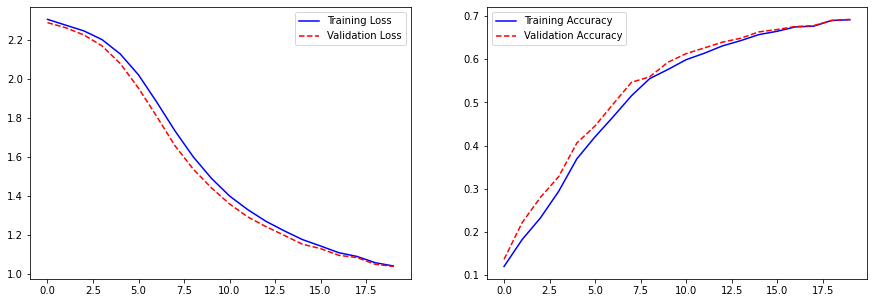

```python
plots(history3)
```

### We see that while the model training improves with a learning rate in between the two extreme values. We can check if it further improves by slightly increasing it

```python
## creating the 4th model

model4 =  Sequential()
model4.add(Dense(256, input_shape = (1024,), activation = 'relu'))
model4.add(Dense(256, activation = 'relu'))
model4.add(Dense(10, activation = 'softmax'))

## optimizer

sgd = optimizers.SGD(lr = 0.03, decay = 1e-6, momentum = 0.9) ## New learning rate of 0.03

## compiling the model

model4.compile(loss = 'categorical_crossentropy', optimizer = sgd, metrics = ['accuracy'])

## fitting the model

history4 = model4.fit(X_train, y_train, epochs = 20, batch_size = 1000, verbose = 1, validation_data= (X_val,y_val))
```

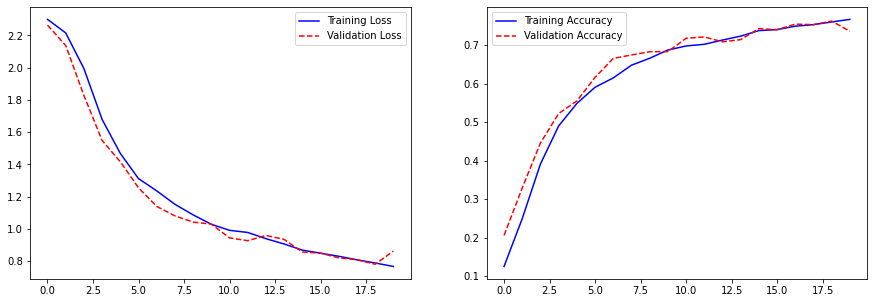

```python
plots(history4)
```